# Regression Part 2

Julia Meinhardt

10/3/2020

```r
library(tidyverse)
library(jtools)
library(interactions)
library(knitr)
```

Estimate at least one more version of the regression you estimated in Assignment 4 by transforming one or more of the independent variables and including at least one interaction term. Which version of the model best explains the observed variation in your dependent variable?

#### Loading Data

```r
Jefferson_Bay <- read.csv("jeffersonbay2018.csv")
```

### Initial Model

```r
model_combined <- lm(cash_assist ~ low_income + pub_assist + majority_grads + majority_college +  majority_bachelors + region,
            data = Jefferson_Bay)

summary(model_combined)
```

```
##
## Call:
## lm(formula = cash_assist ~ low_income + pub_assist + majority_grads +
##     majority_college + majority_bachelors + region, data = Jefferson_Bay)
##
## Residuals:
##       Min        1Q    Median        3Q       Max
## -0.074685 -0.007328 -0.001002  0.006028  0.093806
##
## Coefficients:
##                          Estimate Std. Error t value Pr(>|t|)
## (Intercept)            -0.0006178  0.0017987  -0.343  0.73130
## low_income              0.1512059  0.0038985  38.786  < 2e-16 ***
## pub_assist              0.0127629  0.0047898   2.665  0.00778 **
## majority_gradsTRUE     -0.0001995  0.0012497  -0.160  0.87316
## majority_collegeTRUE    0.0001232  0.0014916   0.083  0.93419
## majority_bachelorsTRUE -0.0062523  0.0008620  -7.254 6.19e-13 ***
## regionJefferson         0.0026973  0.0017104   1.577  0.11497
## ---
## Signif. codes:  0 '***' 0.001 '**' 0.01 '*' 0.05 '.' 0.1 ' ' 1
##
## Residual standard error: 0.01345 on 1666 degrees of freedom
## Multiple R-squared:  0.6541, Adjusted R-squared:  0.6528
## F-statistic:   525 on 6 and 1666 DF,  p-value: < 2.2e-16
```

### Continuous to Categorical

```r
summary(Jefferson_Bay)
```

```
##      NAME             low_income       total_popE      pub_assist
##  Length:1673        Min.   :0.0000   Min.   :   60   Min.   :0.0000
##  Class :character   1st Qu.:0.0744   1st Qu.: 3488   1st Qu.:0.3116
##  Mode  :character   Median :0.1258   Median : 4594   Median :0.3585
##                     Mean   :0.1568   Mean   : 4780   Mean   :0.3645
##                     3rd Qu.:0.2067   3rd Qu.: 5864   3rd Qu.:0.4061
##                     Max.   :0.6133   Max.   :14758   Max.   :0.7424
##   cash_assist       majority_grads  majority_college majority_bachelors
##  Min.   :0.000000   Mode :logical   Mode :logical    Mode :logical
##  1st Qu.:0.008287   FALSE:195       FALSE:1551       FALSE:932
##  Median :0.018449   TRUE :1478      TRUE :122        TRUE :741
##  Mean   :0.024966
##  3rd Qu.:0.035663
##  Max.   :0.188380
##     region             county
##  Length:1673        Length:1673
##  Class :character   Class :character
##  Mode  :character   Mode  :character
##
##
##
```

```r
combined_categorical_frame <- Jefferson_Bay  %>%
  mutate(proportion_income = case_when(low_income < .1568 ~ "Below Average",
                                       low_income > .1568  ~ "Average"))

combined_categorical_r <- lm(cash_assist ~ proportion_income + pub_assist + majority_grads + majority_college +  majority_bachelors + region + county,
            data = combined_categorical_frame)

summary(combined_categorical_r)
```

```
##
## Call:
## lm(formula = cash_assist ~ proportion_income + pub_assist + majority_grads +
##     majority_college + majority_bachelors + region + county,
##     data = combined_categorical_frame)
##
## Residuals:
##       Min        1Q    Median        3Q       Max
## -0.051109 -0.009096 -0.001595  0.007083  0.133827
##
## Coefficients: (1 not defined because of singularities)
##                                  Estimate Std. Error t value Pr(>|t|)
## (Intercept)                     0.0410981  0.0021792  18.859  < 2e-16 ***
## proportion_incomeBelow Average -0.0208867  0.0009764 -21.391  < 2e-16 ***
## pub_assist                      0.0417187  0.0057809   7.217 8.09e-13 ***
## majority_gradsTRUE             -0.0115476  0.0014337  -8.054 1.52e-15 ***
## majority_collegeTRUE           -0.0034596  0.0018605  -1.860 0.063133 .
## majority_bachelorsTRUE         -0.0111797  0.0010304 -10.849  < 2e-16 ***
## regionJefferson                 0.0019089  0.0072824   0.262 0.793257
## countyContraCosta              -0.0021718  0.0013907  -1.562 0.118560
## countyDel Norte                 0.0304804  0.0093533   3.259 0.001142 **
## countyLassen                   -0.0041353  0.0088725  -0.466 0.641221
## countyMarin                    -0.0077224  0.0023242  -3.323 0.000911 ***
## countyModoc                    -0.0128819  0.0106755  -1.207 0.227728
## countyNapa                     -0.0113639  0.0026595  -4.273 2.04e-05 ***
## countyPlumas                   -0.0054666  0.0093336  -0.586 0.558167
## countySan Francisco            -0.0032312  0.0014671  -2.202 0.027774 *
## countySan Mateo                -0.0079112  0.0015390  -5.140 3.07e-07 ***
## countySanta Clara              -0.0068344  0.0011904  -5.741 1.12e-08 ***
## countyShasta                    0.0041212  0.0074722   0.552 0.581338
## countySiskiyou                  0.0103321  0.0082771   1.248 0.212107
## countySolano                    0.0044665  0.0019134   2.334 0.019696 *
## countySonoma                   -0.0050909  0.0018487  -2.754 0.005955 **
## countyTrinity                          NA         NA      NA       NA
## ---
## Signif. codes:  0 '***' 0.001 '**' 0.01 '*' 0.05 '.' 0.1 ' ' 1
##
## Residual standard error: 0.01588 on 1652 degrees of freedom
## Multiple R-squared:  0.5217, Adjusted R-squared:  0.5159
## F-statistic:  90.1 on 20 and 1652 DF,  p-value: < 2.2e-16
```

```r
combined_categorical_frame2 <- Jefferson_Bay  %>%
  mutate(proportion_pub_assist = case_when(pub_assist < .3645 ~ "Below Average",
                                       pub_assist > .3645  ~ "Average"))

combined_categorical_r2 <- lm(cash_assist ~ proportion_pub_assist + majority_grads + majority_college +  majority_bachelors + region,
            data = combined_categorical_frame2)

summary(combined_categorical_r2)
```

```
##
## Call:
## lm(formula = cash_assist ~ proportion_pub_assist + majority_grads +
##     majority_college + majority_bachelors + region, data = combined_categorical_frame2)
##
## Residuals:
##       Min        1Q    Median        3Q       Max
## -0.059973 -0.011178 -0.003392  0.007276  0.154590
##
## Coefficients:
##                                     Estimate Std. Error t value Pr(>|t|)
## (Intercept)                         0.055365   0.001647  33.609  < 2e-16 ***
## proportion_pub_assistBelow Average -0.007901   0.001037  -7.620 4.22e-14 ***
## majority_gradsTRUE                 -0.021575   0.001545 -13.967  < 2e-16 ***
## majority_collegeTRUE               -0.004266   0.002092  -2.040   0.0416 *
## majority_bachelorsTRUE             -0.017480   0.001085 -16.112  < 2e-16 ***
## regionJefferson                     0.017428   0.002364   7.371 2.66e-13 ***
## ---
## Signif. codes:  0 '***' 0.001 '**' 0.01 '*' 0.05 '.' 0.1 ' ' 1
##
## Residual standard error: 0.01892 on 1667 degrees of freedom
## Multiple R-squared:  0.3151, Adjusted R-squared:  0.3131
## F-statistic: 153.4 on 5 and 1667 DF,  p-value: < 2.2e-16
```

### Interaction Term: Region

```r
model_interaction <- lm(cash_assist ~ low_income + pub_assist + majority_grads + majority_college +  majority_bachelors + region +
                        low_income:region + pub_assist:region +majority_grads:region + majority_college:region + majority_bachelors:region,
            data = Jefferson_Bay)


summary(model_interaction)
```

```
##
## Call:
## lm(formula = cash_assist ~ low_income + pub_assist + majority_grads +
##     majority_college + majority_bachelors + region + low_income:region +
##     pub_assist:region + majority_grads:region + majority_college:region +
##     majority_bachelors:region, data = Jefferson_Bay)
##
## Residuals:
##       Min        1Q    Median        3Q       Max
## -0.076047 -0.007335 -0.001035  0.005996  0.094152
##
## Coefficients:
##                                          Estimate Std. Error t value Pr(>|t|)
## (Intercept)                            -0.0001292  0.0018510  -0.070  0.94437
## low_income                              0.1504278  0.0040563  37.085  < 2e-16
## pub_assist                              0.0127484  0.0048574   2.625  0.00876
## majority_gradsTRUE                     -0.0005685  0.0012765  -0.445  0.65611
## majority_collegeTRUE                   -0.0001880  0.0017402  -0.108  0.91400
## majority_bachelorsTRUE                 -0.0063147  0.0008714  -7.246 6.52e-13
## regionJefferson                        -0.0086869  0.0099953  -0.869  0.38492
## low_income:regionJefferson              0.0083480  0.0157145   0.531  0.59533
## pub_assist:regionJefferson             -0.0116073  0.0303208  -0.383  0.70190
## majority_gradsTRUE:regionJefferson      0.0141536  0.0082648   1.713  0.08699
## majority_collegeTRUE:regionJefferson    0.0005477  0.0035751   0.153  0.87826
## majority_bachelorsTRUE:regionJefferson  0.0116470  0.0102414   1.137  0.25560
##
## (Intercept)
## low_income                             ***
## pub_assist                             **
## majority_gradsTRUE
## majority_collegeTRUE
## majority_bachelorsTRUE                 ***
## regionJefferson
## low_income:regionJefferson
## pub_assist:regionJefferson
## majority_gradsTRUE:regionJefferson     .
## majority_collegeTRUE:regionJefferson
## majority_bachelorsTRUE:regionJefferson
## ---
## Signif. codes:  0 '***' 0.001 '**' 0.01 '*' 0.05 '.' 0.1 ' ' 1
##
## Residual standard error: 0.01345 on 1661 degrees of freedom
## Multiple R-squared:  0.6551, Adjusted R-squared:  0.6528
## F-statistic: 286.8 on 11 and 1661 DF,  p-value: < 2.2e-16
```

### Interaction Term: County

```r
model_interaction2 <- lm(cash_assist ~ low_income + pub_assist + majority_grads + majority_college +  majority_bachelors + region +
                        low_income:county + pub_assist:county +majority_grads:county + majority_college:county + majority_bachelors:county,
            data = Jefferson_Bay)


summary(model_interaction2)
```

```
##
## Call:
## lm(formula = cash_assist ~ low_income + pub_assist + majority_grads +
##     majority_college + majority_bachelors + region + low_income:county +
##     pub_assist:county + majority_grads:county + majority_college:county +
##     majority_bachelors:county, data = Jefferson_Bay)
##
## Residuals:
##       Min        1Q    Median        3Q       Max
## -0.071976 -0.006652 -0.000885  0.005866  0.073224
##
## Coefficients: (8 not defined because of singularities)
##                                              Estimate Std. Error t value
## (Intercept)                                 2.281e-03  1.930e-03   1.182
## low_income                                  1.457e-01  6.684e-03  21.798
## pub_assist                                  6.710e-03  8.533e-03   0.786
## majority_gradsTRUE                          4.031e-03  2.191e-03   1.839
## majority_collegeTRUE                       -7.984e-04  6.482e-03  -0.123
## majority_bachelorsTRUE                     -8.814e-03  1.740e-03  -5.066
## regionJefferson                            -1.151e-02  1.265e-02  -0.910
## low_income:countyContraCosta                1.468e-02  1.198e-02   1.225
## low_income:countyDel Norte                  8.806e-02  6.044e-02   1.457
## low_income:countyLassen                    -8.927e-03  6.148e-02  -0.145
## low_income:countyMarin                     -3.324e-02  2.142e-02  -1.552
## low_income:countyModoc                     -5.381e+00  4.041e+00  -1.332
## low_income:countyNapa                      -4.944e-02  4.197e-02  -1.178
## low_income:countyPlumas                    -2.107e-01  1.316e-01  -1.601
## low_income:countySan Francisco             -3.599e-03  1.061e-02  -0.339
## low_income:countySan Mateo                 -2.753e-02  1.691e-02  -1.628
## low_income:countySanta Clara               -1.051e-02  1.105e-02  -0.951
## low_income:countyShasta                     2.721e-02  2.185e-02   1.246
## low_income:countySiskiyou                   9.440e-02  6.070e-02   1.555
## low_income:countySolano                     3.411e-02  1.476e-02   2.311
## low_income:countySonoma                     7.941e-03  1.950e-02   0.407
## low_income:countyTrinity                   -3.954e-01  9.686e-02  -4.082
## pub_assist:countyContraCosta               -2.066e-02  1.413e-02  -1.462
## pub_assist:countyDel Norte                  8.472e-02  7.757e-02   1.092
## pub_assist:countyLassen                    -2.084e-02  1.003e-01  -0.208
## pub_assist:countyMarin                     -1.363e-02  3.336e-02  -0.408
## pub_assist:countyModoc                      4.434e-01  4.060e-01   1.092
```

[output cut: 129 more lines]

```
## majority_bachelorsTRUE:countyPlumas        0.498890
## majority_bachelorsTRUE:countySan Francisco 0.174491
## majority_bachelorsTRUE:countySan Mateo     0.012640 *
## majority_bachelorsTRUE:countySanta Clara   0.030283 *
## majority_bachelorsTRUE:countyShasta        0.172053
## majority_bachelorsTRUE:countySiskiyou            NA
## majority_bachelorsTRUE:countySolano        0.847770
## majority_bachelorsTRUE:countySonoma        0.168072
## majority_bachelorsTRUE:countyTrinity             NA
## ---
## Signif. codes:  0 '***' 0.001 '**' 0.01 '*' 0.05 '.' 0.1 ' ' 1
##
## Residual standard error: 0.01275 on 1599 degrees of freedom
## Multiple R-squared:  0.7015, Adjusted R-squared:  0.6878
## F-statistic: 51.47 on 73 and 1599 DF,  p-value: < 2.2e-16
```

### Comparing Results

This might be in part because I’ve chosen variables that are so obviously related to one another that it is easy to predict proportions of tracts using food stamps based on these other variables. But I think that the fact that region as an interaction term does less to effect my r-squared value than county might mean that region is **not** good at predicting the proportion of people that will be on food stamps, which addresses in part my initial question about the differences between regions. They might not be as different as they seem on the surface in relation to these variables. So perhaps, in fact, this higher r-squared value serves as evidence **against** my original expectation that there would be some significant differences between regions.

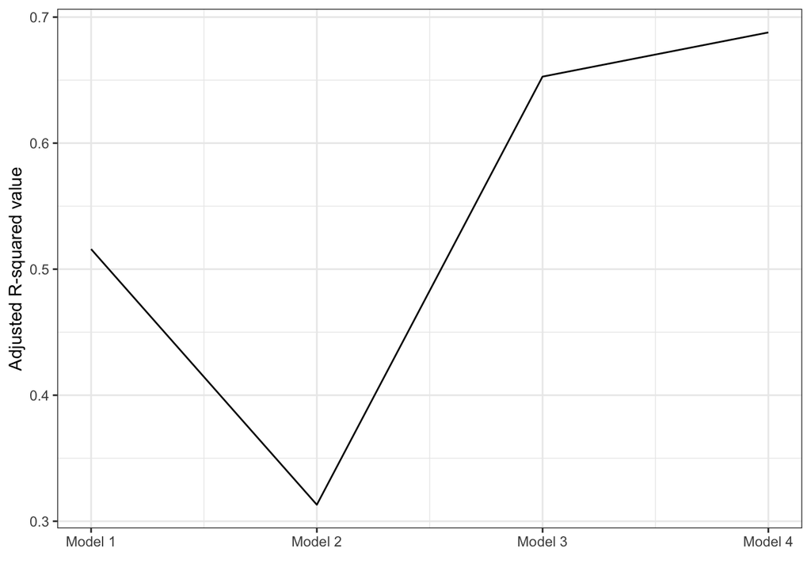

```r
model_fit <- tibble(model = c(1, 2, 3, 4),
                   R_square = c(summary(combined_categorical_r)$adj.r.squared,
                                summary(combined_categorical_r2)$adj.r.squared,
                                summary(model_interaction)$adj.r.squared,
                                summary(model_interaction2)$adj.r.squared))

ggplot(model_fit, aes(x = model, y = R_square)) +
  geom_line() +
  scale_x_continuous(name = "",
                   breaks = breaks <- seq(1, 7, by = 1),
                   labels = paste("Model", breaks)) +
  scale_y_continuous(name = "Adjusted R-squared value") +
  theme_bw()
```